# Bank of America, National Association Customer Complaint Analysis

Author

Hue Nguyen Denke

Published

October 2, 2025

[figure not shown]

# 1 Introduction

This project analyzes the customer narrative complaint from Bank of America to find relationship between customer’s emotion with complaint dispute rate. In this project, I compare the emotional content of disputed vs. non-disputed complaints to identify emotional patterns that might predict complaint resolution difficulty.

Source: `https://www.consumerfinance.gov/data-research/consumer-complaints/#download-the-data`

# 2 Data Dictionary

Our dataset includes the following columns:

`Date.received`: Date that the complaint was received

`Product`: Product that was complaint about (i.e Debt Collection, Mortgage,..)

`Sub.product`: Sub category of the product (i.e Credit Card, Debit Card,…)

`Issue`: Issue category

`Sub.issue`: Sub issue category

`Consumer.complaint.narrative`: Consumer explanation on the issue

`Company.public.response`: Company public response via website or social media

`Company`: Name of bank. Note: Our dataset includes all US banks, but for the range of this project I will filter out only Bank of America

`State`: The state of the mailing address provided by the consumer

`ZIP.code`: The mailing ZIP code provided by the consumer

`Tags`: The department/office that the issue will be directed to

`Consumer.consent.provided.`: Consumer consent to public issue

`Submitted.via`: Platform the issue was submitted

`Date.sent.to.company`: Date that the issue was sent to the bank

`Company.response.to.consumer`: Company resolution to the issue

`Timely.response`: Whether if this is a timely response or not

`Consumer.disputed.`: Whether if the consumer dispute the resolution or not

`Complaint.ID`: The unique identifier of each complaint

# 3 Data Cleaning Methodology To Ensure Tidy Data

Converted all date column from character to `Date` format

```r
data$Date.received <- as.Date(data$Date.received,
                              format = "%Y-%m-%d")

data$Date.sent.to.company <- as.Date(data$Date.sent.to.company,
                              format = "%Y-%m-%d")
```

Standardize empty cells to `NA` format

```r
data$Consumer.complaint.narrative[which(data$Consumer.complaint.narrative == "")] <- NA
```

# 4 Data Summary

Our dataset spans 14 years (2011-12-01 - 2025-09-24) with 11,109,951 complaints.

These complaints come from 7,756 US banks.

The top 5 companies with most complaints are:

1. Equifax, Inc.
2. Transunion Intermediate Holdings, Inc.
3. Experian Information Solutions, Inc.
4. Bank of America
5. Wells Fargo & Company

In the following analysis, we would focus on Bank of America only

# 5 Key Findings

## 5.1 High-level view of the customer complaint

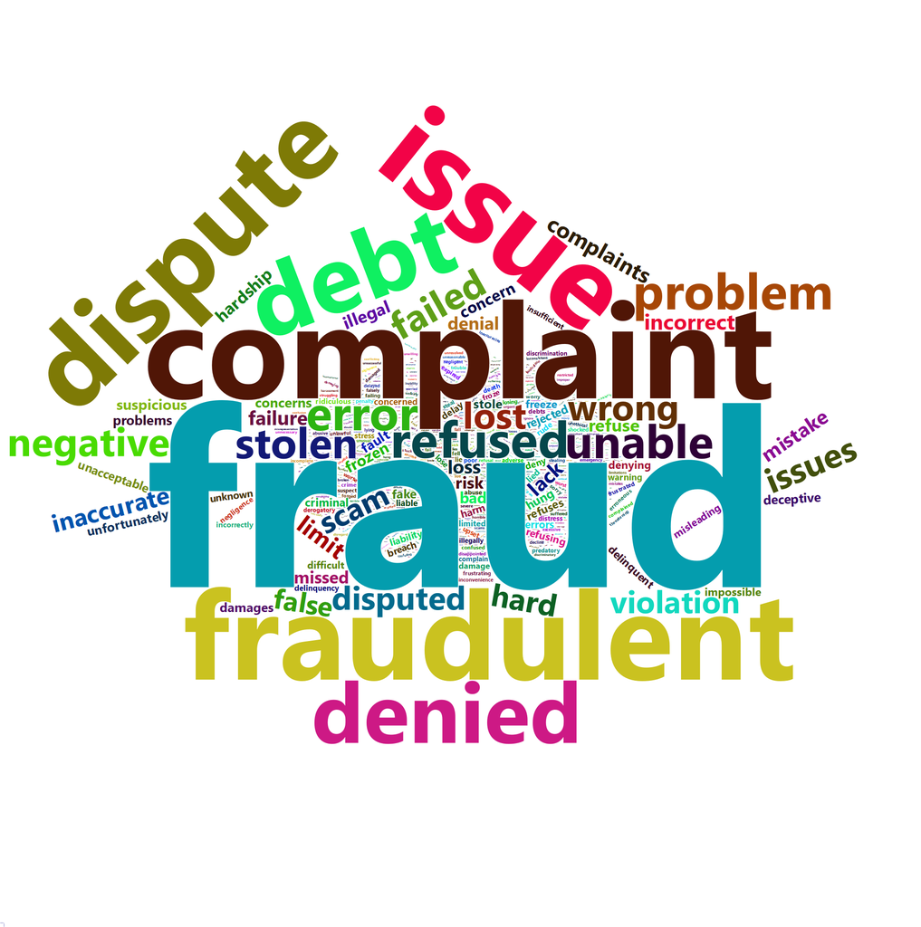

The most common problem are likely related to fraud, debt or denied issue.

## 5.2 Net sentiment emotions related to each product

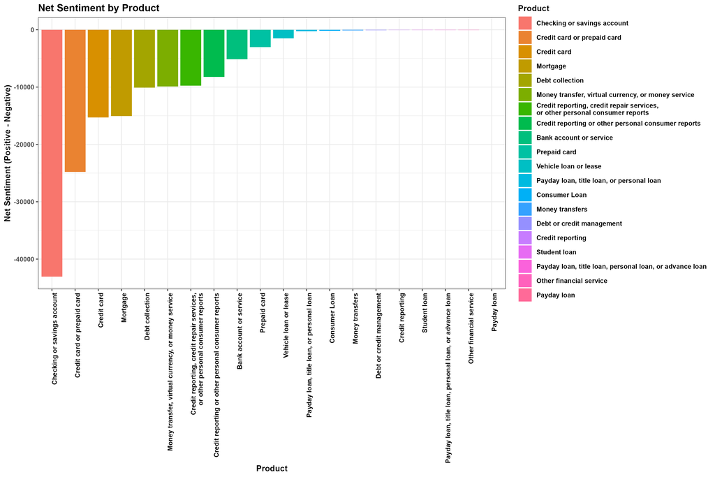

- Net sentiment is the net emotion from each complaint (i.e net sentiment = positive - negative)
- We can see the largest emotion gap is checking or saving accounts, following by credit card or prepaid card, mortgage and debt collection are also observed with large gap
- Since other financial services product is quite general, Bank of America should conduct more analysis on the credit card, prepaid card and debt collection product to identify the root cause that cause negative complaints.

## 5.3 Comparative Analysis using `nrc` sentiment

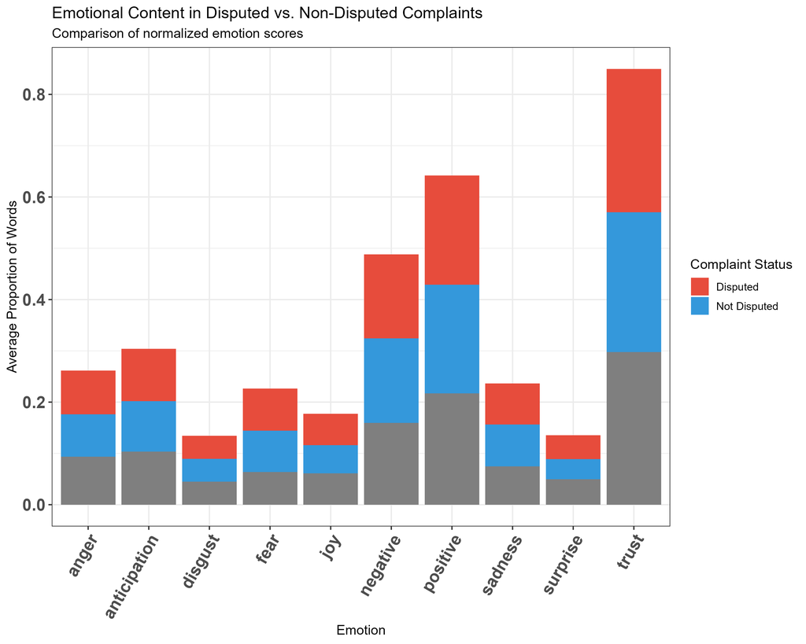

- Method: Compare the emotional content of disputed vs. non-disputed complaints
- Goal: Identify emotional patterns that might predict complaint resolution difficulty
- Result: Largest dispute ratio falls within trust and positive emotions

## 5.4 Perform statistical analysis to find correlation between emotion and dispute rate

**Run model**

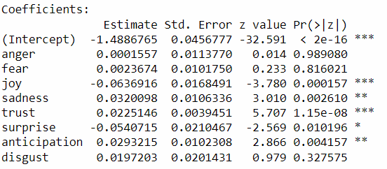

Significant predictors are

`joy` (p = 0.000157): negative relationship

`sadness` (p = 0.002610): positive relationship

`trust` (p = 1.15e-08): positive relationship

`surprise` (p = 0.010196): negative relationship

`anticipation` (p = 0.004157): positive relationship

## 5.5 Validate model with Chi-Squared Test

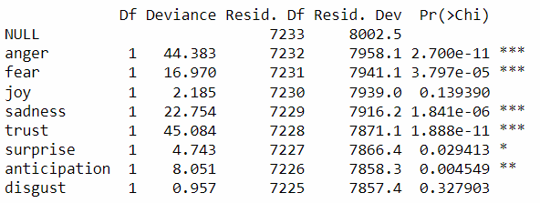

Significant predictors are

Anger (p = 2.700e-11)

Fear (p = 3.797e-05)

Sadness (p = 1.841e-06)

Trust (p = 1.888e-11)

Surprise (p = 0.029413)

Anticipation (p = 0.004549)

Joy is significant in the coefficient test but not in the sequential test, suggesting it may share explanatory power with variables added earlier

Anger is significant in the sequential test but not in the coefficient test

# 6 Final Suggestions

- Focus on sadness, trust, surprise and anticipation as your primary findings since they are significant in both tests
- Acknowledge joy as potentially important since it’s significant when controlling for all variables
- Consider whether to include anger based on your research question and theoretical framework

# 7 R script

[Link](https://github.com/huedenke/project/blob/main/Clean%20R%20Code.R)